# KidSearch Analyses:

## GitHub Documents

Code to reproduce the analyses in manuscript, “Animacy and object size are reflected in preschoolers perceptual similarity computations by the preschool years”

## Step 1: Load packages

```r
library(knitr) # for kable table formating
library(readxl) # import excel files
library(forcats) #manipulating factors in data frames
library(ez) # for anova
library(lme4)
source("SEfunctions.R") ## helper code for within subs error bars
library(tidyverse) # for data munging
```

## Step 1: Load data and choose experiment

```r
## Step 2: Load data
e1 = read_tsv("data/Animacy.txt")
e2 = read_tsv("data/ObjectSize.txt")
e3 = read_tsv("data/Edibility.txt")

## Choose experiment!
#exp = e1
#expName = 'Animacy'

exp = e2
expName = 'Size'
#
#exp = e3
#expName = 'Edibility'
```

## Step 1: Preprocess data

```r
##
exp$subject = as.factor(exp$sub)
exp$conditionNum = as.numeric(exp$condition)
exp$conditionName = as.factor(exp$conditionName)
exp$categoryNum = as.numeric(exp$categoryNum)
exp$category = as.factor(exp$category)

## Step 3: Preprocess data
# count how many trials per subject
trialCount=exp %>%
  dplyr::group_by(subject) %>%
  summarise(trials=sum(phase=='SixItems'), correctTrials=sum(correct==1 & phase=='SixItems'), errors=sum(correct==0 & phase=='SixItems'), slow=sum(RT>4000 & phase=='SixItems' & correct==1))

# what percentage of all trials were incorrect?
round(mean(trialCount$errors/trialCount$trials)*100,2)
```

```
## [1] 21.98
```

```r
# what percentage of correct trials were slow?
round(mean(trialCount$slow/trialCount$correctTrials)*100,2)
```

```
## [1] 10.45
```

```r
# Only get data with correct trials less than 4 seconds long when there were six items on the screen.
exp.tidy=exp %>%
  filter(RT<4000) %>%
  filter(correct==1) %>%
  filter(phase=='SixItems') %>%
  filter(repeatDist==0) # for technical error trials in experiment 3 only.

# make log RT
exp.tidy$logRT=log(exp.tidy$RT);

# Now only include subjects who had more than 1 trial speeded trial in each of 4 conditions
exp.tidy=exp.tidy %>%
  group_by(subject) %>%
  mutate(indivCountC1=sum(conditionNum==1 & categoryNum==1)) %>%
  mutate(indivCountC2=sum(conditionNum==1 & categoryNum==2)) %>%
  mutate(indivCountC3=sum(conditionNum==2 & categoryNum==1)) %>%
  mutate(indivCountC4=sum(conditionNum==2 & categoryNum==2)) %>%
  filter(indivCountC1>1) %>%
  filter(indivCountC2>1) %>%
  filter(indivCountC3>1) %>%
  filter(indivCountC4>1)

# Store included subs
includedSubs=unique(exp.tidy$subject)

# How many trials are included in each condition in this subset of children?
trialCountIncludedSubs=exp.tidy %>%
  group_by(subject) %>%
  filter(is.element(subject,includedSubs)) %>%
  summarise(trialCount=length(RT), uniformCount=sum(conditionNum==1), mixedCount=sum(conditionNum==2))

# overall how many trials (and sd)
round(mean(trialCountIncludedSubs$trialCount),2)
```

```
## [1] 34.33
```

```r
round(sd(trialCountIncludedSubs$trialCount),2)
```

```
## [1] 16.53
```

```r
# how many trials on average per condition?
round(mean(trialCountIncludedSubs$uniformCount),2)
```

```
## [1] 17.02
```

```r
round(mean(trialCountIncludedSubs$mixedCount),2)
```

```
## [1] 17.3
```

```r
# Compute accuracy means
exp.accuracy=exp %>%
  group_by(subject,conditionName, category) %>%
  filter(phase=='SixItems') %>%
  filter(repeatDist==0) %>% # for technical error trials in experiment 3 only.
  filter(is.element(subject,includedSubs)) %>% # only use subs included in RT anlayses for consistency
  summarise(meanAcc = mean(correct)) # average wtihin subjects
```

## Step 3: Accuracy results

```r
# summarize accuracy results
condAccMeans=exp.accuracy %>%
  group_by(conditionName) %>%
  summarize(avgCondAcc=mean(meanAcc), sdCondRT=sd(meanAcc))

categAccMeans=exp.accuracy %>%
  group_by(category) %>%
  summarize(avgCondAcc=mean(meanAcc), sdCondRT=sd(meanAcc))

# descriptive means (mixed v uniform)
UniMixAcc=round(condAccMeans$avgCondAcc*100,2)
CategoryAccs=round(categAccMeans$avgCondAcc*100,2)

# ANOVA
accuracyResults=ezANOVA(dv= .(meanAcc), wid= .(subject), within= .(conditionName, category), detailed=TRUE, data=data.frame(exp.accuracy), type=3)
partialEtaSquared=accuracyResults$ANOVA$SSn/(accuracyResults$ANOVA$SSn + accuracyResults$ANOVA$SSd)
```

Children were 80.86% accurate on mixed trials, and 82.59% on uniform category trials.

Children were 80.21% accurate on BigFam trials, and 83.24% on SmallFam trials.

Effect of condition on accuracy: (*F*(1,45)= 0.88, *p* = 0.35, *partial eta squared*= 0.02

Effect of category on accuracy: (*F*(1,45)= 4.01, *p* = 0.05, *partial eta squared*= 0.08

Effect of their interaction on accuracy: (*F*(1,45)= 0.49, *p* = 0.49, *partial eta squared*= 0.01

## Step 4: RT results

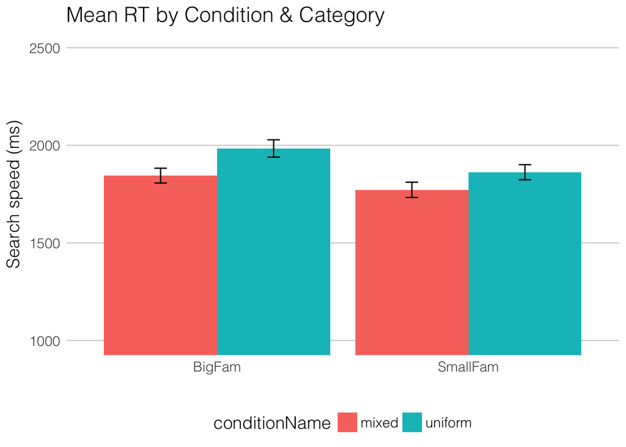

```r
## Calculate descriptive statistics: Means and SD
avgByCondAndCat=exp.tidy %>%
  group_by(conditionName,category,subject) %>%
  summarise(meanRT= mean(RT))

avgByCondAndCatLog=exp.tidy %>%
  dplyr::group_by(conditionName,category,subject) %>%
  summarise(medLog = median(logRT))


# Report descriptives
condMeans=avgByCondAndCat %>%
  group_by(conditionName) %>%
  summarize(avgCondRT=mean(meanRT), sdCondRT=sd(meanRT))

UniMixRT=round(condMeans$avgCondRT,0)
UniMixRT_SDs=round(condMeans$sdCondRT,0)

# now by category
categoryMeans=avgByCondAndCat %>%
  group_by(category) %>%
  summarize(avgCatRT=mean(meanRT), sdCatRT=sd(meanRT))

# output category means
CategoryRT=round(categoryMeans$avgCatRT,0)
Category_SDs=round(categoryMeans$sdCatRT,0)

## Inferential statistics: ANOVA and mixed-effects model
RTResults=ezANOVA(dv= .(RT), wid= .(subject), within= .(conditionName, category), detailed=TRUE, data=data.frame(exp.tidy), type=3)
partialEtaSquaredRT=RTResults$ANOVA$SSn/(RTResults$ANOVA$SSn + RTResults$ANOVA$SSd)

## with log RT?
RTResults=ezANOVA(dv= .(logRT), wid= .(subject), within= .(conditionName, category), detailed=TRUE, data=data.frame(exp.tidy), type=3)
partialEtaSquaredRT=RTResults$ANOVA$SSn/(RTResults$ANOVA$SSn + RTResults$ANOVA$SSd)


# Save cleaned data for e1 and e2 to compare them in next sript.
#tidyFileName = paste(expName,"_Tidy.txt",sep="")
#write.table(exp.tidy, file = tidyFileName, sep="\t")

## Cohens DZ calculation
avgByCond=exp.tidy %>%
  group_by(conditionName,subject) %>%
  summarise(meanRT= mean(RT))
effectBySub=avgByCond$meanRT[avgByCond$conditionName=='uniform']-avgByCond$meanRT[avgByCond$conditionName=='mixed']
dz=mean(effectBySub)/sd(effectBySub)

# ## get summary for plotting
plotSummary=summarySEwithin(data=exp.tidy, measurevar="RT", withinvars=c("conditionName","category"), idvar="subject")

#
# ## Make plot
library(ggthemes)
library(ggplot2)
plotLimits=c(1000,2500)
dodge <- position_dodge(width = 0.9)
ggplot(plotSummary, aes(x=category,y=RT, fill=conditionName)) +
  geom_bar(stat="identity", position=dodge) +  # plot the point
  geom_errorbar(aes(ymin=RT-se, ymax=RT+se), width=.1, position=dodge) + # make some error bars
  coord_cartesian(ylim=plotLimits) + # ugh, need this for some reason with bar plots - sorry
  theme_hc(base_size=14)  + ## change ggplot theme, number here modulates size of text
  theme(axis.ticks.x=element_blank(),    axis.ticks.y=element_blank()) +
  theme(text=element_text(family="Helvetica Light")) + # I just think this is agood font
  labs(x="", y="Search speed (ms)") + # kill redudant x label +
  ggtitle("Mean RT by Condition & Category")
```

Children took 1846ms on mixed category trials, and 1975ms on uniform category trials.

Children took 1973ms on BigFam trials, and 1849ms on SmallFam trials.

Effect of condition on RT: (*F*(1,45)= 9.23, *p* = 0, *partial eta squared*= 0.17

Effect of category on RT: (*F*(1,45) = 9.09, *p* = 0, *partial eta squared*= 0.17

Effect of their interaction on RT: (*F*(1,45) = 0.61, *p* = 0.44, *partial eta squared*= 0.01

Cohens DZ for condition of interest (uniform vs. mixed): Cohens *dz* = 0.46

```r
##Inferential statistics: Mixed-effects models
# Fixed effects of category and condition, and random effects of subjects and target items on the intercept, and random slopes for the effect of condition on subjects

# Note: no effect modeled of condition on targetItems; model fails to converge.

# Maximum model
exp.MaxModel <- lmer(RT ~ category*conditionName + (1 + conditionName|sub) + (1+ conditionName|targetItem), data=exp.tidy, REML=TRUE)

## Do we need random slopes on subjects?
exp.ModelMod1 <- lmer(RT ~ category*conditionName + (1|sub) + (1+ conditionName|targetItem), data=exp.tidy, REML=TRUE)
summary(exp.ModelMod1)
```

```
## Linear mixed model fit by REML ['lmerMod']
## Formula: RT ~ category * conditionName + (1 | sub) + (1 + conditionName |
##     targetItem)
##    Data: exp.tidy
##
## REML criterion at convergence: 25182.3
##
## Scaled residuals:
##     Min      1Q  Median      3Q     Max
## -1.9960 -0.7428 -0.1866  0.6091  3.1792
##
## Random effects:
##  Groups     Name                 Variance Std.Dev. Corr
##  sub        (Intercept)           53275   230.8
##  targetItem (Intercept)           15124   123.0
##             conditionNameuniform  15499   124.5    -0.76
##  Residual                        476971   690.6
## Number of obs: 1579, groups:  sub, 46; targetItem, 40
##
## Fixed effects:
##                                       Estimate Std. Error t value
## (Intercept)                            1895.04      56.86   33.33
## categorySmallFam                        -86.59      62.86   -1.38
## conditionNameuniform                    136.19      57.59    2.36
## categorySmallFam:conditionNameuniform   -46.68      80.38   -0.58
##
## Correlation of Fixed Effects:
##             (Intr) ctgrSF cndtnN
## ctgrySmllFm -0.561
## cndtnNmnfrm -0.558  0.504
## ctgrySmlF:N  0.399 -0.712 -0.716
```

```r
anova(exp.ModelMod1,exp.MaxModel) # if no difference, can remove random slopes on subjects
```

```
## Data: exp.tidy
## Models:
## exp.ModelMod1: RT ~ category * conditionName + (1 | sub) + (1 + conditionName |
## exp.ModelMod1:     targetItem)
## exp.MaxModel: RT ~ category * conditionName + (1 + conditionName | sub) + (1 +
## exp.MaxModel:     conditionName | targetItem)
##               Df   AIC   BIC logLik deviance  Chisq Chi Df Pr(>Chisq)
## exp.ModelMod1  9 25239 25287 -12610    25221
## exp.MaxModel  11 25242 25301 -12610    25220 0.6317      2     0.7292
```

```r
## Do we need random slopes on items?
exp.ModelMod2 <- lmer(RT ~ category*conditionName + (1|sub) + (1|targetItem), data=exp.tidy, REML=TRUE)
summary (exp.ModelMod2)
```

```
## Linear mixed model fit by REML ['lmerMod']
## Formula: RT ~ category * conditionName + (1 | sub) + (1 | targetItem)
##    Data: exp.tidy
##
## REML criterion at convergence: 25184.3
##
## Scaled residuals:
##     Min      1Q  Median      3Q     Max
## -2.0301 -0.7368 -0.1875  0.6197  3.1726
##
## Random effects:
##  Groups     Name        Variance Std.Dev.
##  sub        (Intercept)  52833   229.85
##  targetItem (Intercept)   7495    86.57
##  Residual               480762   693.37
## Number of obs: 1579, groups:  sub, 46; targetItem, 40
##
## Fixed effects:
##                                       Estimate Std. Error t value
## (Intercept)                            1894.53      53.36   35.51
## categorySmallFam                        -87.93      56.54   -1.56
## conditionNameuniform                    136.72      50.56    2.70
## categorySmallFam:conditionNameuniform   -42.50      70.26   -0.60
##
## Correlation of Fixed Effects:
##             (Intr) ctgrSF cndtnN
## ctgrySmllFm -0.540
## cndtnNmnfrm -0.464  0.438
## ctgrySmlF:N  0.333 -0.616 -0.719
```

```r
anova(exp.ModelMod1,exp.ModelMod2) # if no difference, can remove random slopes on items
```

```
## Data: exp.tidy
## Models:
## exp.ModelMod2: RT ~ category * conditionName + (1 | sub) + (1 | targetItem)
## exp.ModelMod1: RT ~ category * conditionName + (1 | sub) + (1 + conditionName |
## exp.ModelMod1:     targetItem)
##               Df   AIC   BIC logLik deviance  Chisq Chi Df Pr(>Chisq)
## exp.ModelMod2  7 25236 25274 -12611    25222
## exp.ModelMod1  9 25239 25287 -12610    25221 1.4846      2      0.476
```

```r
# null model - no fixed factor of condition or it's interactino (i.e., uniform/mixed), same random effects structure
exp.NullModel <- lmer(RT ~ category + (1 |sub) + (1 |targetItem), data=exp.tidy, REML=FALSE)

# Essential model comparison
anova(exp.NullModel,exp.ModelMod2)
```

```
## Data: exp.tidy
## Models:
## exp.NullModel: RT ~ category + (1 | sub) + (1 | targetItem)
## exp.ModelMod2: RT ~ category * conditionName + (1 | sub) + (1 | targetItem)
##               Df   AIC   BIC logLik deviance  Chisq Chi Df Pr(>Chisq)
## exp.NullModel  5 25243 25270 -12617    25233
## exp.ModelMod2  7 25236 25274 -12611    25222 11.016      2   0.004055 **
## ---
## Signif. codes:  0 '***' 0.001 '**' 0.01 '*' 0.05 '.' 0.1 ' ' 1
```

Summary:

E1: Animacy: Maximum model fails to converge, as does a model with either random slopes on subjects or random slopes on target items. Probably because less data overall than E2 or E3.

E2: Object Size: Maximum models and models with random slopes do converge. Random slopes have somewhat high correlation with the intercept, but don’t explain extra variance.

E3:Edibility: Random effect of condition on subjects (i.e., “(1 + conditionName|sub)”) had a perfect negative correlation with the intercept, suggesting that it was not explaining variance. Similarily, the random effects of condition on items also had a very high negative correlation with the intercept.